# R Notebook

Initially, I began this presentation attempting to determine which stats I could filter from the regular season that is most correlated to wins and championships. Initially having three point makes, rebounds and points in the paint which I quickly had to change for several reasons. Circling back, I decided to analyze cluster the team’s based on four categories, Three Point Attempts, Assists, FG, fg_3pt.

I chose these specific stats because I feel like they encapsulate the main characteristics of the modern NBA and offenses. The best offenses tend to lead successful teams and after testing this hypothesis, the data reflected that, for the most part.

```r
library(tidyverse)
library(waffle)
#install.packages("hoopR")
# You can install using the pacman package using the following code:
if (!requireNamespace('pacman', quietly = TRUE)){
  install.packages('pacman')
}
library(hoopR)
library(dplyr)
library(tidyverse)
library(cluster)
library(tidyverse)
library(ggbeeswarm)
library(ggrepel)

set.seed(1234)
```

```r
tictoc::tic()
progressr::with_progress({
  nba_team_box <- hoopR::load_nba_team_box(2016:2021)
})
tictoc::toc()
```

```
2.144 sec elapsed
```

In this column, I had to seperate columns in half in order to have two seperate data inputs. This will become more helpful later on. Also, this data came as characters not numbers, so I also adjusted that here.

```r
nba_team_box_better <- nba_team_box %>%
  separate(three_point_field_goals_made_three_point_field_goals_attempted, c('three_point_makes', 'three_point_attempts'),"-") %>%
  separate(free_throws_made_free_throws_attempted, c('free_throw_makes', 'free_throw_attempts'),"-") %>%
  mutate(three_point_makes= as.numeric(three_point_makes), three_point_attempts= as.numeric(three_point_attempts ), total_rebounds= as.numeric(total_rebounds), total_turnovers =as.numeric(total_turnovers), points_in_paint= as.numeric(points_in_paint), assists= as.numeric(assists), free_throw_makes =as.numeric(free_throw_makes),free_throw_attempts= as.numeric(free_throw_attempts), field_goal_pct= as.numeric(field_goal_pct), three_point_field_goal_pct= as.numeric(three_point_field_goal_pct))
```

Here I filtered out teams that aren’t actual NBA teams.

```r
nba_team_box_better <- nba_team_box_better %>%
  filter(team_display_name!= "All-Stars", team_display_name!= "Team LeBron", team_display_name!= "World", team_display_name!= "USA", team_display_name!= "Team Stephen", team_display_name!= "Team Giannis", team_display_name!= "Team Durant")
```

I completed the following step for each corresponding year from 2016- 2021 in reverse chronological order.

```r
NBA2022 <- nba_team_box_better %>%
filter(game_date >= '2020-12-20', game_date <= '2021-05-19') %>%
group_by (team_display_name) %>%
summarize(avg_3pt = sum(three_point_makes)/sum(three_point_attempts)*100) %>%
  arrange(desc(avg_3pt))
```

```r
Totals2021 <- nba_team_box_better %>%
filter(game_date >= '2020-12-20', game_date <= '2021-05-19') %>%
group_by (team_display_name) %>%
  summarise(three_point_attempts = sum(three_point_attempts), Assists = sum(assists), FG = mean(field_goal_pct), FTA = sum(free_throw_attempts), fg_3pt= mean(three_point_field_goal_pct))
```

Grouping key statistics that I focused on throughout the process.

```r
Turnovers <- nba_team_box_better %>%
filter(game_date >= '2020-12-20', game_date <= '2021-05-19') %>%
  group_by (team_display_name) %>%
  summarise(all_turnovers = sum(total_turnovers))
```

```r
PIP <- nba_team_box_better %>%
filter(game_date >= '2020-12-20', game_date <= '2021-05-19') %>%
  group_by (team_display_name) %>%
  summarise(sum(points_in_paint))
```

```r
Assists <- nba_team_box_better %>%
filter(game_date >= '2020-12-20', game_date <= '2021-05-19') %>%
  group_by (team_display_name) %>%
  summarise(sum(assists))
```

```r
ThreePointAttempts <- nba_team_box_better %>%
filter(game_date >= '2020-12-20', game_date <= '2021-05-19') %>%
  group_by (team_display_name) %>%
  summarise(sum(three_point_attempts))
```

The stats within the select are the categories I used to group each team for clustering. This code helped me determine how many clusters would work best.

```r
TotalScale_2021 <- Totals2021 %>%
  select(three_point_attempts, Assists, FG,fg_3pt) %>%
  mutate_all(scale) %>%
  na.omit()
```

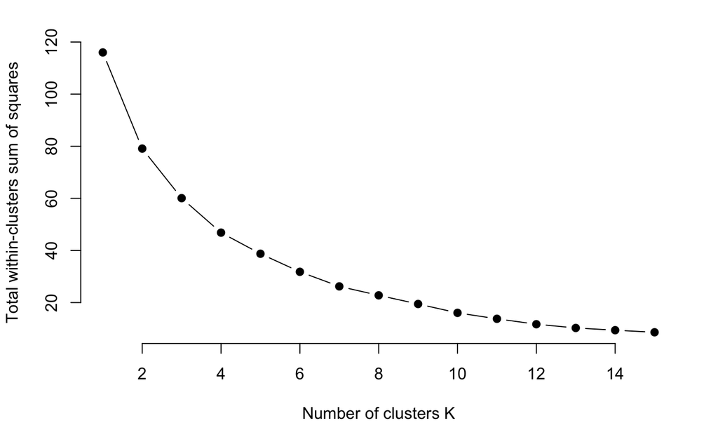

```r
 # function to compute total within-cluster sum of square
wss <- function(k) {
  kmeans(TotalScale_2021, k, nstart = 10 )$tot.withinss
}

# Compute and plot wss for k = 1 to k = 15
k.values <- 1:15

# extract wss for 2-15 clusters
wss_values <- map_dbl(k.values, wss)

plot(k.values, wss_values,
       type="b", pch = 19, frame = FALSE,
       xlab="Number of clusters K",
       ylab="Total within-clusters sum of squares")
```

```r
NA
NA
```

```r
k6_2021 <- kmeans(TotalScale_2021, centers = 6, nstart = 10)
```

This is the dataframe to create the cluster chart.

```r
k6_2021
```

```
K-means clustering with 6 clusters of sizes 3, 5, 6, 5, 5, 6

Cluster means:
  three_point_attempts    Assists          FG      fg_3pt
1         -0.916066794 -0.9414925  0.03739212  0.74216192
2          1.291945577 -0.9414925 -0.30373098  0.53507948
3         -1.061153556  0.3763960  0.37758477 -0.66230937
4          0.181940024  0.6957547  1.37507617  1.24933419
5          0.354574904  1.1902455  0.14183417  0.04757704
6         -0.004530135 -0.6927395 -1.40726363 -1.23543051

Clustering vector:
 [1] 1 2 4 5 5 6 2 4 6 5 6 5 4 3 3 5 4 6 3 1 6 6 1 4 2 3 3 2 2 3

Within cluster sum of squares by cluster:
[1]  3.270343  6.402011  3.920043  4.692934  3.024151 10.505307
 (between_SS / total_SS =  72.6 %)

Available components:

[1] "cluster"      "centers"      "totss"        "withinss"     "tot.withinss" "betweenss"
[7] "size"         "iter"         "ifault"
```

```r
teamcluster_2021 <- data.frame(Totals2021, k6_2021$cluster)
champ2021 <- teamcluster_2021 %>%
  filter(team_display_name == "Milwaukee Bucks")
```

Here, I am adding a wins column to add an extra layer of analysis.

```r
standings2021 <- espn_nba_standings(2021) %>% mutate(season = 2021)

teamcluster_2021 <- teamcluster_2021 %>% inner_join(standings2021, by=c("team_display_name"="team"))

teamcluster_2021 <- teamcluster_2021 %>% mutate(wins = as.numeric(wins))
```

```r
wins_2021 <- teamcluster_2021%>%
  filter(wins >= 46) %>%
  group_by(team_display_name, fg_3pt, three_point_attempts) %>%
  summarise(wins = wins, fg_3pt =fg_3pt, three_point_attempts = three_point_attempts) %>%
  arrange(desc(wins))
```

This is used to isolate the Bucks (in this case) in order to plot them individually on the chart. It also allows me to compare the Bucks to other team’s in their cluster.

```r
Bucks <- teamcluster_2021 %>% filter(team_display_name == "Milwaukee Bucks")

cluster4<- teamcluster_2021 %>% filter(k6_2021.cluster == 4)
```

Now, I can graph specifically based on three point attempts and corresponding percentage, also factoring wins.

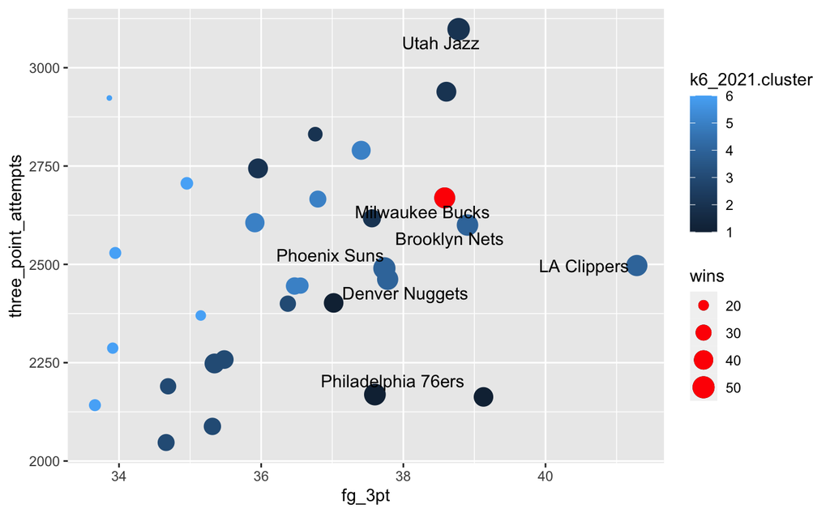

```r
ggplot() +
  geom_point(data=teamcluster_2021, aes(x=fg_3pt, y=three_point_attempts, size = wins, color=k6_2021.cluster)) +
geom_point(data=Bucks, aes(x=fg_3pt, y=three_point_attempts, size = wins), colour = 'red')+
  geom_text_repel(
    data=wins_2021,
    aes(x=fg_3pt, y=three_point_attempts, label=team_display_name))
```

This exact process was repeated for every season… Here are the results! #2020 Season

```r
NBA2020 <- nba_team_box_better %>%
filter(game_date >= '2019-10-21', game_date <= '2020-08-15') %>%
group_by (team_display_name) %>%
summarize(avg_3pt = sum(three_point_makes)/sum(three_point_attempts)*100) %>%
  arrange(desc(avg_3pt))
```

```r
Totals2020 <- nba_team_box_better %>%
filter(game_date >= '2019-10-21', game_date <= '2020-08-15') %>%
 group_by (team_display_name) %>%
  summarise(ThreePointAttempts = sum(three_point_attempts), Assists = sum(assists), FG = mean(field_goal_pct), FTA = sum(free_throw_attempts), fg_3pt= mean(three_point_field_goal_pct))
```

```r
TotalScale2020 <- Totals2020 %>%
select(ThreePointAttempts, Assists, FG, fg_3pt) %>%
  mutate_all(scale) %>%
  na.omit()
```

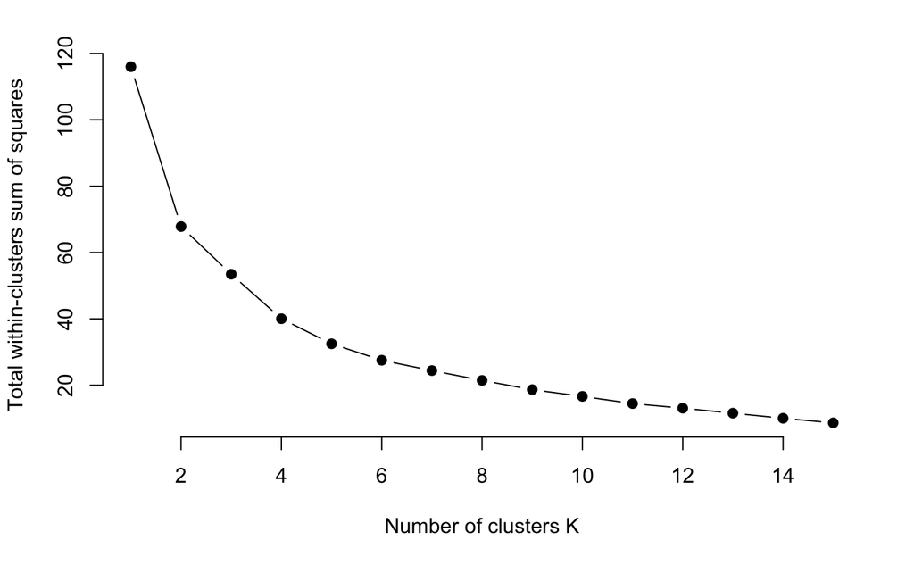

```r
 # function to compute total within-cluster sum of square
wss <- function(k) {
  kmeans(TotalScale2020, k, nstart = 10 )$tot.withinss
}

# Compute and plot wss for k = 1 to k = 15
k.values <- 1:15

# extract wss for 2-15 clusters
wss_values <- map_dbl(k.values, wss)

plot(k.values, wss_values,
       type="b", pch = 19, frame = FALSE,
       xlab="Number of clusters K",
       ylab="Total within-clusters sum of squares")
```

```r
NA
NA
```

When I attempt to make another cluster, it overwrites the previous one. How do I fix that?

```r
k6_2020 <- kmeans(TotalScale2020, centers = 6, nstart = 10)
```

```r
k6_2020
```

```
K-means clustering with 6 clusters of sizes 2, 5, 7, 7, 3, 6

Cluster means:
  ThreePointAttempts    Assists         FG      fg_3pt
1        1.926132413 -0.3377612 -0.8879295 -0.82768768
2        1.127606177  0.9079601  0.4542323  0.87725442
3        0.006891568 -0.2210234  0.4169771  0.95585779
4       -0.519994577 -0.8661075 -1.4066045 -1.21535018
5       -0.957168907 -1.1529076  0.1127627 -0.08469865
6       -0.504511320  1.2007268  1.0156336 -0.11005901

Clustering vector:
 [1] 4 3 1 4 4 5 2 6 5 4 1 6 3 6 6 2 2 4 2 4 5 4 6 6 3 3 3 2 3 3

Within cluster sum of squares by cluster:
[1] 2.149172 5.646385 5.905349 8.288409 1.589498 3.943879
 (between_SS / total_SS =  76.3 %)

Available components:

[1] "cluster"      "centers"      "totss"        "withinss"     "tot.withinss" "betweenss"
[7] "size"         "iter"         "ifault"
```

```r
teamcluster_2020 <- data.frame(Totals2020, k6_2020$cluster)
```

```r
standings2020 <- espn_nba_standings(2020) %>% mutate(season = 2020)

teamcluster_2020 <- teamcluster_2020 %>% inner_join(standings2020, by=c("team_display_name"="team"))

teamcluster_2020 <- teamcluster_2020 %>% mutate(wins = as.numeric(wins))
```

```r
wins_2020 <- teamcluster_2020 %>%
  filter(wins >= 46) %>%
  group_by(team_display_name, fg_3pt, ThreePointAttempts) %>%
  summarise(wins = wins, fg_3pt =fg_3pt, ThreePointAttempts = ThreePointAttempts) %>%
  arrange(desc(wins))
```

```r
Lakers <- teamcluster_2020 %>% filter(team_display_name == "Los Angeles Lakers")
cluster5_2020<- teamcluster_2020 %>% filter(k6_2020.cluster == 5)
```

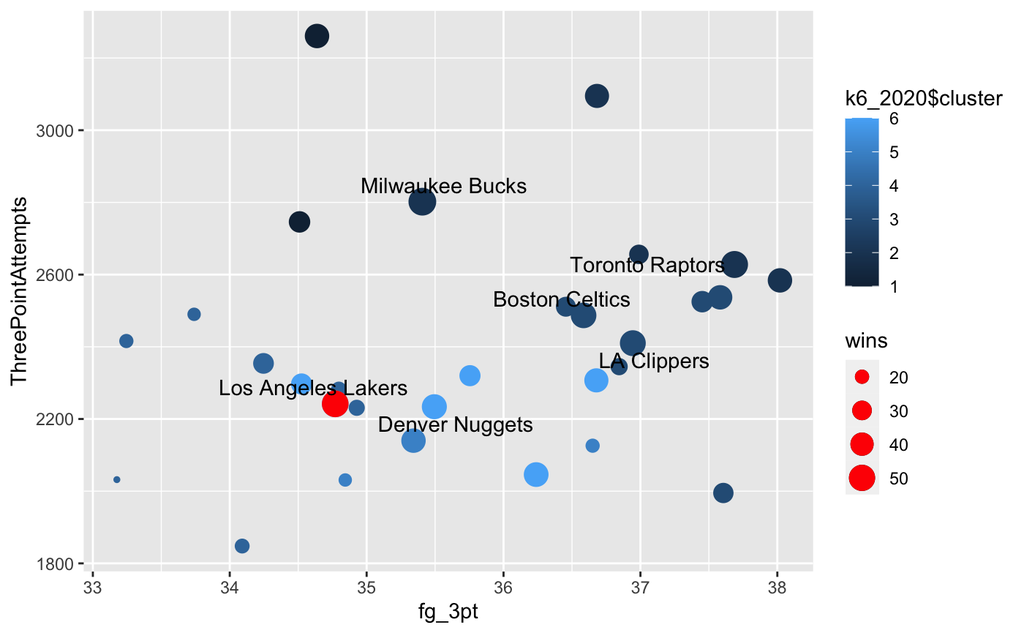

```r
ggplot() +
  geom_point(data=teamcluster_2020, aes(x=fg_3pt, y=ThreePointAttempts, color=k6_2020$cluster, size=wins)) +
  geom_point(data=Lakers, aes(x=fg_3pt, y=ThreePointAttempts, size=wins), colour= "red")+
  geom_text_repel(
    data=wins_2020,
    aes(x=fg_3pt, y=ThreePointAttempts, label=team_display_name))
```

Analyzing this chart and the corresponding clustering, the Lakers are actually an outlier among the champions. However, they fall in the same cluster as the Denver Nuggets who they faced in the Western Conference Finals.

#2019 season

```r
NBA2019 <- nba_team_box_better %>%
filter(game_date >= '2018-10-16', game_date <= '2019-04-10') %>%
  group_by (team_display_name) %>%
summarize(avg_3pt = sum(three_point_makes)/sum(three_point_attempts)*100) %>%
  arrange(desc(avg_3pt))
```

```r
Totals2019 <- nba_team_box_better %>%
filter(game_date >= '2018-10-16', game_date <= '2019-04-10') %>%
  group_by (team_display_name) %>%
  summarise(ThreePointAttempts = sum(three_point_attempts), Assists = sum(assists), FG = mean(field_goal_pct), FTA = sum(free_throw_attempts), fg_3pt= mean(three_point_field_goal_pct))
```

```r
NBA2019 <- nba_team_box_better %>%
filter(game_date >= '2018-10-16', game_date <= '2019-04-10') %>%
  group_by (team_display_name) %>%
summarize(avg_3pt = sum(three_point_makes)/sum(three_point_attempts)*100) %>%
  arrange(desc(avg_3pt))
```

```r
Totals2019 <- nba_team_box_better %>%
filter(game_date >= '2018-10-16', game_date <= '2019-04-10') %>%
  group_by (team_display_name) %>%
 group_by (team_display_name) %>%
  summarise(ThreePointAttempts = sum(three_point_attempts), Assists = sum(assists), FG = mean(field_goal_pct), FTA = sum(free_throw_attempts), fg_3pt= mean(three_point_field_goal_pct))
```

```r
TotalScale2019 <- Totals2019 %>%
select(ThreePointAttempts, Assists, FG, fg_3pt) %>%
  mutate_all(scale) %>%
  na.omit()
```

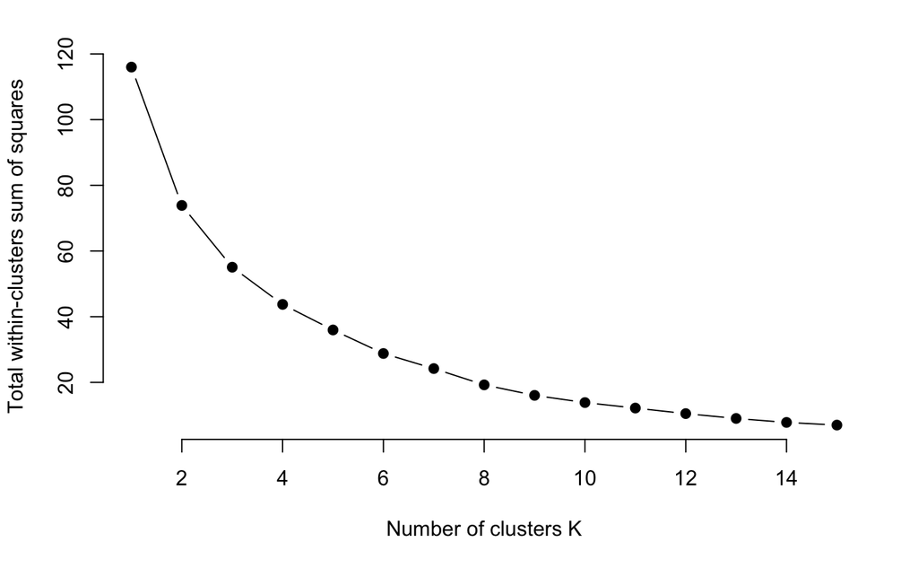

```r
 # function to compute total within-cluster sum of square
wss <- function(k) {
  kmeans(TotalScale2019, k, nstart = 10 )$tot.withinss
}

# Compute and plot wss for k = 1 to k = 15
k.values <- 1:15

# extract wss for 2-15 clusters
wss_values <- map_dbl(k.values, wss)

plot(k.values, wss_values,
       type="b", pch = 19, frame = FALSE,
       xlab="Number of clusters K",
       ylab="Total within-clusters sum of squares")
```

```r
NA
NA
```

```r
k6_2019 <- kmeans(TotalScale2019, centers = 6, nstart = 10)
```

```r
k6_2019
```

```
K-means clustering with 6 clusters of sizes 9, 5, 4, 1, 10, 1

Cluster means:
  ThreePointAttempts    Assists         FG      fg_3pt
1          0.2333211  0.8625381  0.7301216 -0.26533774
2         -0.7978654 -1.1708557 -0.9704122 -0.86224047
3         -1.2673426  0.1585938  0.8678380  1.78957092
4          3.1864533 -1.4831875 -0.7920714 -0.08858961
5          0.3213953 -0.3305900 -0.6657049 -0.22051308
6          0.5584019  2.2461472  2.2587345  1.83467876

Clustering vector:
 [1] 5 1 5 5 2 2 5 1 5 6 4 3 3 1 2 5 1 5 1 2 5 5 1 2 5 3 3 1 1 1

Within cluster sum of squares by cluster:
[1] 8.265731 7.382870 3.728204 0.000000 9.337636 0.000000
 (between_SS / total_SS =  75.2 %)

Available components:

[1] "cluster"      "centers"      "totss"        "withinss"     "tot.withinss" "betweenss"
[7] "size"         "iter"         "ifault"
```

```r
teamcluster_2019 <- data.frame(Totals2019, k6_2019$cluster)
```

```r
standings2019 <- espn_nba_standings(2019) %>% mutate(season = 2019)

teamcluster_2019 <- teamcluster_2019 %>% inner_join(standings2019, by=c("team_display_name"="team"))

teamcluster_2019 <- teamcluster_2019 %>% mutate(wins = as.numeric(wins))

wins_2019 <- teamcluster_2019 %>%
  filter(wins >= 51) %>%
  group_by(team_display_name, fg_3pt, ThreePointAttempts) %>%
  summarise(wins = wins, fg_3pt =fg_3pt, ThreePointAttempts = ThreePointAttempts) %>%
  arrange(desc(wins))
```

```r
Raptors <- teamcluster_2019 %>% filter(team_display_name == "Toronto Raptors")
cluster4_2019<- teamcluster_2019 %>% filter(k6_2019.cluster == 4)
```

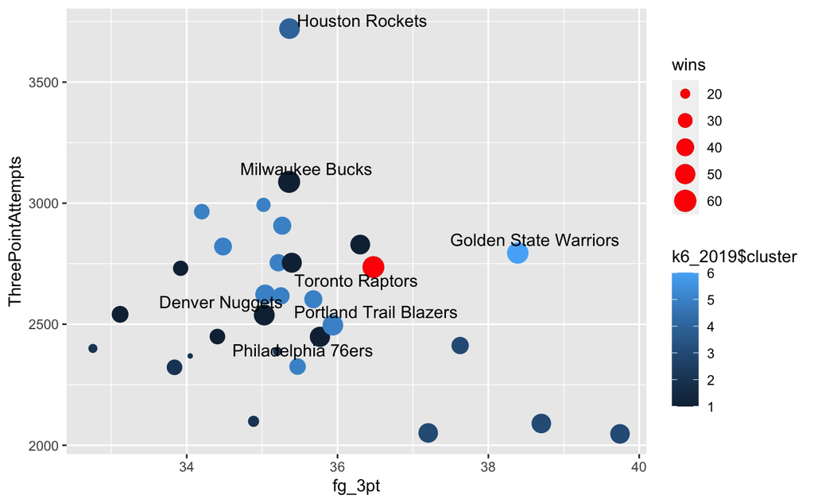

```r
ggplot() +
  geom_point(data=teamcluster_2019, aes(x=fg_3pt, y=ThreePointAttempts, color=k6_2019$cluster, size=wins)) +
  geom_point(data=Raptors, aes(x=fg_3pt, y=ThreePointAttempts, size=wins), colour= "red")+
  geom_text_repel(
    data=wins_2019,
    aes(x=fg_3pt, y=ThreePointAttempts, label=team_display_name))
```

#2018

```r
NBA2018 <- nba_team_box_better %>%
filter(game_date >= '2017-10-17', game_date <= '2018-04-11') %>%
  group_by (team_display_name) %>%
summarize(avg_3pt = sum(three_point_makes)/sum(three_point_attempts)*100) %>%
  arrange(desc(avg_3pt))
```

```r
Totals2018 <- nba_team_box_better %>%
filter(game_date >= '2017-10-17', game_date <= '2018-04-11') %>%
  group_by (team_display_name) %>%
  summarise(ThreePointAttempts = sum(three_point_attempts), Assists = sum(assists), FG = mean(field_goal_pct), FTA = sum(free_throw_attempts), fg_3pt= mean(three_point_field_goal_pct))
```

```r
NBA2018 <- nba_team_box_better %>%
filter(game_date >= '2017-10-17', game_date <= '2018-04-11') %>%
  group_by (team_display_name) %>%
summarize(avg_3pt = sum(three_point_makes)/sum(three_point_attempts)*100) %>%
  arrange(desc(avg_3pt))
```

```r
Totals2018 <- nba_team_box_better %>%
filter(game_date >= '2017-10-17', game_date <= '2018-04-11') %>%
 group_by (team_display_name) %>%
  summarise(ThreePointAttempts = sum(three_point_attempts), Assists = sum(assists), FG = mean(field_goal_pct), FTA = sum(free_throw_attempts), fg_3pt= mean(three_point_field_goal_pct))
```

```r
TotalScale2018 <- Totals2018 %>%
select(ThreePointAttempts, Assists, FG, fg_3pt) %>%
  mutate_all(scale) %>%
  na.omit()
```

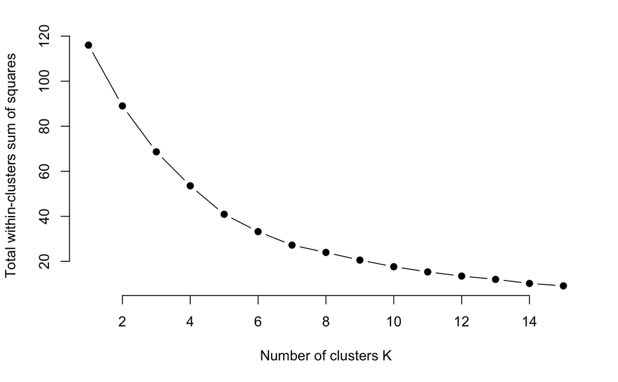

```r
 # function to compute total within-cluster sum of square
wss <- function(k) {
  kmeans(TotalScale2018, k, nstart = 10 )$tot.withinss
}

# Compute and plot wss for k = 1 to k = 15
k.values <- 1:15

# extract wss for 2-15 clusters
wss_values <- map_dbl(k.values, wss)

plot(k.values, wss_values,
       type="b", pch = 19, frame = FALSE,
       xlab="Number of clusters K",
       ylab="Total within-clusters sum of squares")
```

```r
NA
NA
```

```r
k6_2018 <- kmeans(TotalScale2018, centers = 6, nstart = 10)
```

```r
k6_2018
```

```
K-means clustering with 6 clusters of sizes 1, 5, 6, 7, 5, 6

Cluster means:
  ThreePointAttempts     Assists         FG      fg_3pt
1         0.07629446  3.43213901  1.8689400  2.31127364
2        -0.06097346 -0.07519392 -1.4336487 -1.37337466
3        -0.51894726 -0.69580129 -0.3807314  0.97440240
4         0.23734247  0.65320121  0.3801174  0.18484883
5        -1.20818541  0.31725655  0.6951106 -0.61627152
6         1.28696436 -0.84000881  0.2412194  0.08276684

Clustering vector:
 [1] 6 3 6 3 6 6 6 4 3 1 6 3 2 2 5 4 5 5 4 5 2 2 4 2 4 3 5 4 4 3

Within cluster sum of squares by cluster:
[1]  0.000000  4.772189  7.110388  6.847757  3.429348 11.068560
 (between_SS / total_SS =  71.4 %)

Available components:

[1] "cluster"      "centers"      "totss"        "withinss"     "tot.withinss" "betweenss"
[7] "size"         "iter"         "ifault"
```

```r
teamcluster_2018 <- data.frame(Totals2018, k6_2018$cluster)
```

```r
standings2018 <- espn_nba_standings(2018) %>% mutate(season = 2018)

teamcluster_2018 <- teamcluster_2018 %>% inner_join(standings2018, by=c("team_display_name"="team"))

teamcluster_2018 <- teamcluster_2018%>% mutate(wins = as.numeric(wins))

wins_2018 <- teamcluster_2018 %>%
  filter(wins >= 49) %>%
  group_by(team_display_name, fg_3pt, ThreePointAttempts) %>%
  summarise(wins = wins, fg_3pt =fg_3pt, ThreePointAttempts = ThreePointAttempts) %>%
  arrange(desc(wins))
```

```r
Warriors <- teamcluster_2018 %>% filter(team_display_name == "Golden State Warriors")
cluster5_2018 <- teamcluster_2018 %>% filter(k6_2018.cluster == 5)
```

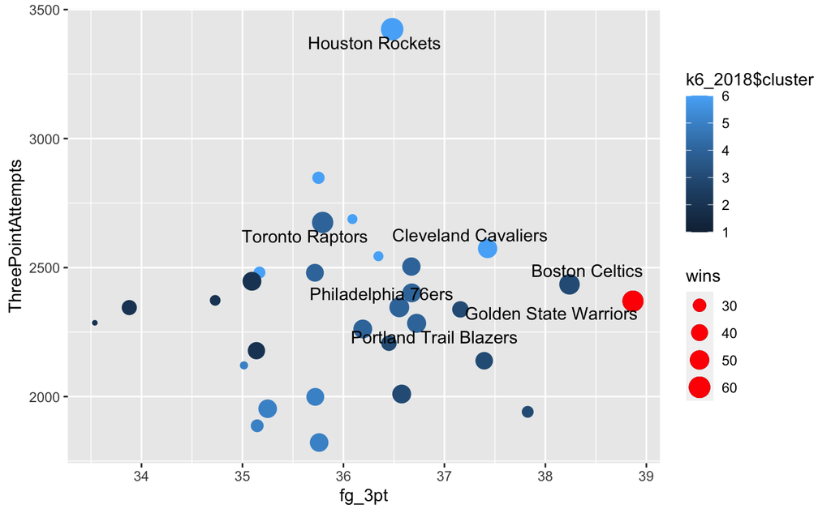

```r
ggplot() +
  geom_point(data=teamcluster_2018, aes(x=fg_3pt, y=ThreePointAttempts, color=k6_2018$cluster, size=wins)) +
  geom_point(data=Warriors, aes(x=fg_3pt, y=ThreePointAttempts, size=wins), colour= "red")+
  geom_text_repel(
    data=wins_2018,
    aes(x=fg_3pt, y=ThreePointAttempts, label=team_display_name))
```

Based on the clustering and the chart, the Warriors were unquestionably the best shooting team in basketball. They marched to an easy title in 2018 and are thought to be one of the greatest team’s in NBA history. Again, the data supports our hypothesis.

#2017

```r
NBA2017 <- nba_team_box_better %>%
filter(game_date >= '2016-10-25', game_date <= '2017-04-14') %>%
  group_by (team_display_name) %>%
summarize(avg_3pt = sum(three_point_makes)/sum(three_point_attempts)*100) %>%
  arrange(desc(avg_3pt))
```

```r
Totals2017 <- nba_team_box_better %>%
filter(game_date >= '2016-10-25', game_date <= '2017-04-14') %>%
  group_by (team_display_name) %>%
  summarise(ThreePointAttempts = sum(three_point_attempts), Assists = sum(assists), FG = mean(field_goal_pct), FTA = sum(free_throw_attempts), fg_3pt= mean(three_point_field_goal_pct))
```

```r
NBA2017 <- nba_team_box_better %>%
filter(game_date >= '2016-10-25', game_date <= '2017-04-14') %>%
  group_by (team_display_name) %>%
summarize(avg_3pt = sum(three_point_makes)/sum(three_point_attempts)*100) %>%
  arrange(desc(avg_3pt))
```

```r
Totals2017 <- nba_team_box_better %>%
filter(game_date >= '2016-10-25', game_date <= '2017-04-14') %>%
  group_by (team_display_name) %>%
  summarise(ThreePointAttempts = sum(three_point_attempts), Assists = sum(assists), FG = mean(field_goal_pct), FTA = sum(free_throw_attempts), fg_3pt= mean(three_point_field_goal_pct))
```

```r
TotalScale2017 <- Totals2017 %>%
select(ThreePointAttempts, Assists, FG, fg_3pt) %>%
  mutate_all(scale) %>%
  na.omit()
```

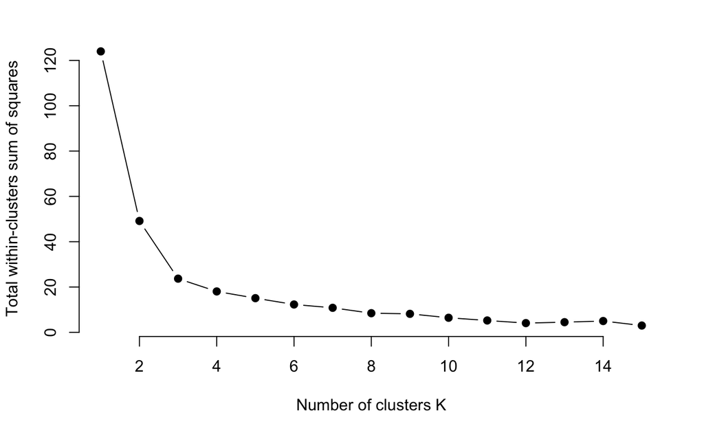

```r
 # function to compute total within-cluster sum of square
wss <- function(k) {
  kmeans(TotalScale2017, k, nstart = 10 )$tot.withinss
}

# Compute and plot wss for k = 1 to k = 15
k.values <- 1:15

# extract wss for 2-15 clusters
wss_values <- map_dbl(k.values, wss)

plot(k.values, wss_values,
       type="b", pch = 19, frame = FALSE,
       xlab="Number of clusters K",
       ylab="Total within-clusters sum of squares")
```

```r
NA
NA
```

```r
k6_2017 <- kmeans(TotalScale2017, centers = 6, nstart = 10)
```

```r
k6_2017
```

```
K-means clustering with 6 clusters of sizes 5, 10, 3, 2, 10, 2

Cluster means:
  ThreePointAttempts    Assists          FG      fg_3pt
1        -0.17062818  0.0107652 -0.55999347 -1.38684211
2         0.21850689  0.1723087 -0.54966190 -0.55734563
3         0.55537168  0.7563830  0.41072944  1.63308955
4        -3.23904334 -3.5434024  3.46570025 -0.17476506
5         0.04370138  0.1660148  0.05426388  0.78437909
6         1.52151490  0.6902970 -0.20482064  0.05706873

Clustering vector:
 [1] 2 6 2 2 1 3 2 5 1 4 3 6 5 5 2 2 5 5 2 2 2 1 1 2 1 5 5 3 5 5 5 4

Within cluster sum of squares by cluster:
[1] 0.6344716 3.3130911 2.6478981 2.3674370 2.8763515 0.4517474
 (between_SS / total_SS =  90.1 %)

Available components:

[1] "cluster"      "centers"      "totss"        "withinss"     "tot.withinss" "betweenss"
[7] "size"         "iter"         "ifault"
```

```r
teamcluster_2017 <- data.frame(Totals2017, k6_2017$cluster)
```

```r
standings2017 <- espn_nba_standings(2017) %>% mutate(season = 2017)

teamcluster_2017 <- teamcluster_2017 %>% inner_join(standings2017, by=c("team_display_name"="team"))

teamcluster_2017 <- teamcluster_2017 %>% mutate(wins = as.numeric(wins))


wins_2017 <- teamcluster_2017 %>%
  filter(wins >= 51) %>%
  group_by(team_display_name, fg_3pt, ThreePointAttempts) %>%
  summarise(wins = wins, fg_3pt =fg_3pt, ThreePointAttempts = ThreePointAttempts) %>%
  arrange(desc(wins))
```

```r
Warriors2017 <- teamcluster_2017 %>% filter(team_display_name == "Golden State Warriors")

cluster3_2017<- teamcluster_2017 %>% filter(k6_2017.cluster == 3)
```

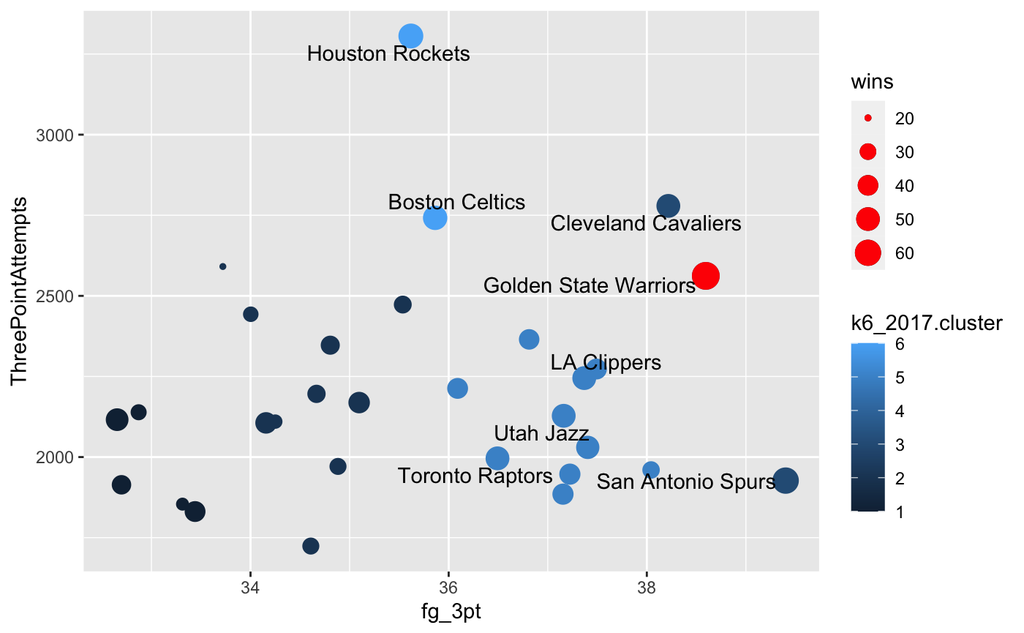

```r
ggplot() +
  geom_point(data=teamcluster_2017, aes(x=fg_3pt, y=ThreePointAttempts, size = wins, color=k6_2017.cluster)) +
geom_point(data=Warriors2017, aes(x=fg_3pt, y=ThreePointAttempts, size = wins), colour = 'red') +
  geom_text_repel(
    data=wins_2017,
    aes(x=fg_3pt, y=ThreePointAttempts, label=team_display_name))
```

Based on the clustering and the chart, the Warriors were again unquestionably one the best shooting team in basketball. After battling off a scare from the Rockets, the Warriors would go on to defeat the Cavs and win their first title with Kevin Durant. #2016

```r
NBA2016 <- nba_team_box_better %>%
filter(game_date >= '2015-10-27', game_date <= '2016-04-14') %>%
  group_by (team_display_name) %>%
summarize(avg_3pt = sum(three_point_makes)/sum(three_point_attempts)*100) %>%
  arrange(desc(avg_3pt))
```

```r
Totals2016 <- nba_team_box_better %>%
filter(game_date >= '2015-10-27', game_date <= '2016-04-14') %>%
  group_by (team_display_name) %>%
  summarise(ThreePointAttempts = sum(three_point_attempts), Assists = sum(assists), FG = mean(field_goal_pct), FTA = sum(free_throw_attempts), fg_3pt= mean(three_point_field_goal_pct))
```

```r
NBA2016 <- nba_team_box_better %>%
filter(game_date >= '2015-10-27', game_date <= '2016-04-14') %>%
  group_by (team_display_name) %>%
summarize(avg_3pt = sum(three_point_makes)/sum(three_point_attempts)*100) %>%
  arrange(desc(avg_3pt))
```

```r
Totals2016 <- nba_team_box_better %>%
filter(game_date >= '2015-10-27', game_date <= '2016-04-14') %>%
  group_by (team_display_name) %>%
  summarise(ThreePointAttempts = sum(three_point_attempts), Assists = sum(assists), FG = mean(field_goal_pct), FTA = sum(free_throw_attempts), fg_3pt= mean(three_point_field_goal_pct))
```

```r
TotalScale2016 <- Totals2016 %>%
select(ThreePointAttempts, Assists, FG, fg_3pt) %>%
  mutate_all(scale) %>%
  na.omit()
```

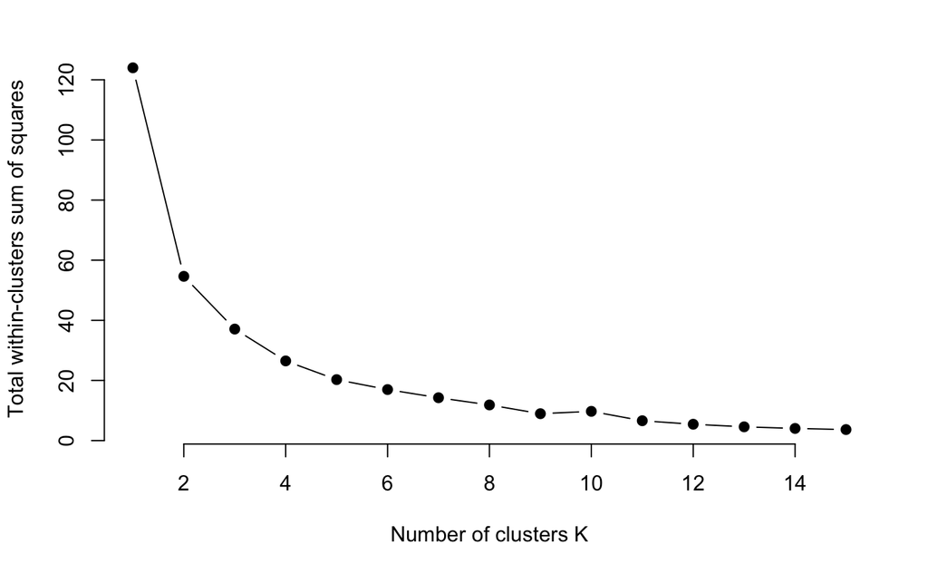

```r
 # function to compute total within-cluster sum of square
wss <- function(k) {
  kmeans(TotalScale2016, k, nstart = 10 )$tot.withinss
}

# Compute and plot wss for k = 1 to k = 15
k.values <- 1:15

# extract wss for 2-15 clusters
wss_values <- map_dbl(k.values, wss)

plot(k.values, wss_values,
       type="b", pch = 19, frame = FALSE,
       xlab="Number of clusters K",
       ylab="Total within-clusters sum of squares")
```

```r
NA
NA
```

```r
k6_2016 <- kmeans(TotalScale2016, centers = 6, nstart = 10)
```

```r
k6_2016
```

```
K-means clustering with 6 clusters of sizes 8, 5, 10, 6, 1, 2

Cluster means:
  ThreePointAttempts     Assists           FG     fg_3pt
1        0.406020373  0.03781545 -0.816537188 -0.8003908
2       -0.740852272  0.19690480  0.029971910 -0.7883307
3        0.002029023  0.25338998 -0.009620411  0.3693107
4        0.888812629  0.31177915 -0.156810348  0.3745330
5        1.271592778  1.38965178  1.043953480  3.2963796
6       -3.084330200 -3.54063704  3.187775339  0.5540477

Clustering vector:
 [1] 4 1 2 4 3 4 1 1 1 6 5 4 3 4 1 2 2 2 2 3 1 3 3 1 1 4 3 3 3 3 3 6

Within cluster sum of squares by cluster:
[1] 3.781051 1.900564 6.226219 2.085749 0.000000 3.307811
 (between_SS / total_SS =  86.0 %)

Available components:

[1] "cluster"      "centers"      "totss"        "withinss"     "tot.withinss" "betweenss"
[7] "size"         "iter"         "ifault"
```

```r
teamcluster_2016 <- data.frame(Totals2016, k6_2016$cluster)
```

```r
standings2016 <- espn_nba_standings(2016) %>% mutate(season = 2016)

teamcluster_2016 <- teamcluster_2016 %>% inner_join(standings2016, by=c("team_display_name"="team"))

teamcluster_2016 <- teamcluster_2016 %>% mutate(wins = as.numeric(wins))

wins_2016 <- teamcluster_2016 %>%
  filter(wins >= 48) %>%
  group_by(team_display_name, fg_3pt, ThreePointAttempts) %>%
  summarise(wins = wins, fg_3pt =fg_3pt, ThreePointAttempts = ThreePointAttempts) %>%
  arrange(desc(wins))
```

```r
Cavs <- teamcluster_2016 %>% filter(team_display_name == "Cleveland Cavaliers")
cluster2_2016<- teamcluster_2016 %>% filter(k6_2016.cluster == 2)
```

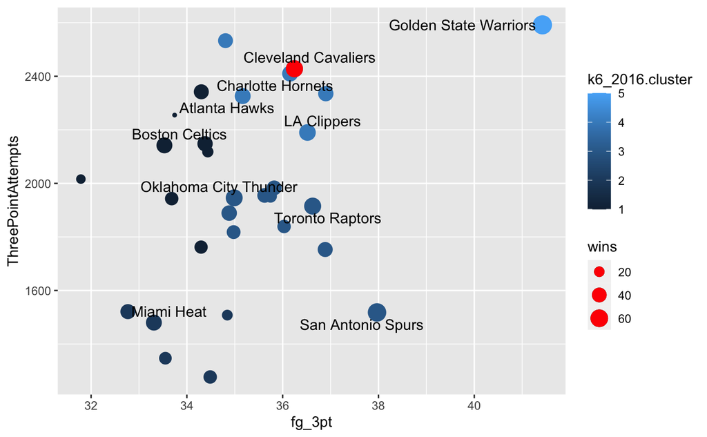

```r
ggplot() +
  geom_point(data=teamcluster_2016, aes(x=fg_3pt, y=ThreePointAttempts, size = wins, color=k6_2016.cluster)) +
geom_point(data=Cavs, aes(x=fg_3pt, y=ThreePointAttempts, size = wins), colour = 'red') +
  geom_text_repel(
    data=wins_2016,
    aes(x=fg_3pt, y=ThreePointAttempts, label=team_display_name))
```

Cavs defeat Warriors in Finals. Cleveland defeated the Hawks in the ECF, who had defeated the Celtics in the first run. They went on to beat a Warriors team that also defeated Portland in the playoffs, who beat the Clippers. They also beat OKC in the WCF, who had beaten the Spurs in the round prior.

Conclusions: Before figuring out cluster: I chose these specific statistics because I feel that they are key indicators of potential success, especially over an 82 game season. While turnovers are not ideal, they are also a bi-product of high efficiency, quick moving offenses. Therefore, it would be interesting to further determine how this stat factors into crowning an NBA champion. Points in the paint and three point makes are specifically relevant because in the modern NBA, during the regular season, teams are looking for open three or open layups consistently. The best teams are able to live in these areas and therefore become strong indicators of winning. Assists again highlight the strength of a high powered offense, with worse teams tending to generate less assists. Rebounding works in a similar manner, giving insight into potentially the quality of a team’s defense or their effectiveness cleaning up their own misses.